# HW3-EDA with R - Part 2: Group by analysis

misken

January 22, 2018

## Step 1 - Familiarize yourself with the data and the assignment

In this assignment you’ll do some exploratory data analysis with R on a dataset US census information based on the [American Community Survey](https://www.census.gov/programs-surveys/acs/). The version of this data that we’ll be using is from a Kaggle dataset. See https://www.kaggle.com/muonneutrino/us-census-demographic-data/data and look at the column metadata for the county level table to see what the various columns mean.

As we did in class, you’ll be creating an R Markdown document to both prepare a dataset and do some analysis as well as to document the steps you did (and answer some questions I’ll throw at you).

You’ll notice a few “Hacker Extra” tasks thrown in. These are for those of you who want to go a little above and beyond and attempt some more challenging tasks.

## Step 2 - Create a new R Markdown document

Save this file as a new R Markdown document and name it **HW3_EDA2wR_[*your last name*].Rmd**. Mine would be called **HW3_EDA2wR_isken.Rmd**. Save it into the same folder as this file.

This will be your working directory.

## Step 3 - Set working directory and explore data folder

Create an R Studio project in the current folder. You’ll notice that there is a folder named **data**. Inside of it you’ll find the data files for this assignment:

- **acs2015_census_tract_data.csv**
- **acs2015_county_data.csv**
- **us_census_bureau_regions_and_divisions.csv**
- **county_MI.csv**

The first two files are from the Kaggle site for this dataset. The last file, **county_MI.csv**, is a file that I created and just contains data from Michigan. The R script, **census_data_prep.R** was used to create the file as well as to merge information from the **us_census_bureau_regions_and_divisions.csv** file with the county data.

## Step 4 - Complete the following R tasks and answer questions

Now you’ll need to complete the following tasks in R. Just like we did in class, you should use a combination of markdown text (be concise, no need to write tons of text) to explain what you are doing and R code chunks to actually do it. When you are done, use the “Knit” button to generate an HTML file from your R Markdown. You’ll be submitting BOTH the completed R Markdown file as well as the generated HTML file. You’ll notice that I’ve left some empty code chunks as well as some partially filled in code chunks. Of course, feel free to add more code chunks as needed.

Let’s load a few libraries we’ll need:

```r
library(plyr)
library(dplyr)
```

```r
library(ggplot2)
```

Let’s read in the data.

```r
county_df <- read.csv(file='data/county.csv')
county_MI <- read.csv(file='data/county_MI.csv')
```

The county_MI data frame contains data for Michigan only and includes an peninsula field. See **census_data_prep.R** to see how this field was created. It involves scraping a table out of a web page.

### Problem 1 - Basic filtering

Use county_MI.

Using basic R commands (i.e. **no plyr or dplyr**) list all the rows for counties in the Upper Peninsula.

```r
county_MI[county_MI$peninsula == 'UP',]
```

```
##         County peninsula    State CensusId State.Code  Region
## 2        Alger        UP Michigan    26003         MI Midwest
## 7       Baraga        UP Michigan    26013         MI Midwest
## 17    Chippewa        UP Michigan    26033         MI Midwest
## 21       Delta        UP Michigan    26041         MI Midwest
## 22   Dickinson        UP Michigan    26043         MI Midwest
## 27     Gogebic        UP Michigan    26053         MI Midwest
## 31    Houghton        UP Michigan    26061         MI Midwest
## 36        Iron        UP Michigan    26071         MI Midwest
## 42    Keweenaw        UP Michigan    26083         MI Midwest
## 48        Luce        UP Michigan    26095         MI Midwest
## 49    Mackinac        UP Michigan    26097         MI Midwest
## 52   Marquette        UP Michigan    26103         MI Midwest
## 55   Menominee        UP Michigan    26109         MI Midwest
## 66   Ontonagon        UP Michigan    26131         MI Midwest
```

[output cut: 97 more lines]

Now do the same thing but use dplyr. Do NOT use the pipe operator.

```r
filter(county_MI, county_MI$peninsula == 'UP')
```

```
##         County peninsula    State CensusId State.Code  Region
## 1        Alger        UP Michigan    26003         MI Midwest
## 2       Baraga        UP Michigan    26013         MI Midwest
## 3     Chippewa        UP Michigan    26033         MI Midwest
## 4        Delta        UP Michigan    26041         MI Midwest
## 5    Dickinson        UP Michigan    26043         MI Midwest
## 6      Gogebic        UP Michigan    26053         MI Midwest
## 7     Houghton        UP Michigan    26061         MI Midwest
## 8         Iron        UP Michigan    26071         MI Midwest
## 9     Keweenaw        UP Michigan    26083         MI Midwest
## 10        Luce        UP Michigan    26095         MI Midwest
## 11    Mackinac        UP Michigan    26097         MI Midwest
## 12   Marquette        UP Michigan    26103         MI Midwest
## 13   Menominee        UP Michigan    26109         MI Midwest
## 14   Ontonagon        UP Michigan    26131         MI Midwest
```

[output cut: 97 more lines]

Repeat using dplyr and using the pipe operator.

```r
#county_MI
county_MI %>%
  filter(peninsula == 'UP')
```

```
##         County peninsula    State CensusId State.Code  Region
## 1        Alger        UP Michigan    26003         MI Midwest
## 2       Baraga        UP Michigan    26013         MI Midwest
## 3     Chippewa        UP Michigan    26033         MI Midwest
## 4        Delta        UP Michigan    26041         MI Midwest
## 5    Dickinson        UP Michigan    26043         MI Midwest
## 6      Gogebic        UP Michigan    26053         MI Midwest
## 7     Houghton        UP Michigan    26061         MI Midwest
## 8         Iron        UP Michigan    26071         MI Midwest
## 9     Keweenaw        UP Michigan    26083         MI Midwest
## 10        Luce        UP Michigan    26095         MI Midwest
## 11    Mackinac        UP Michigan    26097         MI Midwest
## 12   Marquette        UP Michigan    26103         MI Midwest
## 13   Menominee        UP Michigan    26109         MI Midwest
## 14   Ontonagon        UP Michigan    26131         MI Midwest
```

[output cut: 97 more lines]

List rows for counties with population greater than or equal to 200000. Use dplyr.

```r
county_MI %>%
  filter(TotalPop >= 200000)
```

```
##      County peninsula    State CensusId State.Code  Region
## 1   Genesee        LP Michigan    26049         MI Midwest
## 2    Ingham        LP Michigan    26065         MI Midwest
## 3 Kalamazoo        LP Michigan    26077         MI Midwest
## 4      Kent        LP Michigan    26081         MI Midwest
## 5    Macomb        LP Michigan    26099         MI Midwest
## 6   Oakland        LP Michigan    26125         MI Midwest
## 7    Ottawa        LP Michigan    26139         MI Midwest
## 8 Washtenaw        LP Michigan    26161         MI Midwest
## 9     Wayne        LP Michigan    26163         MI Midwest
##             Division TotalPop    Men  Women Hispanic White Black Native
## 1 East North Central   415874 200473 215401      3.2  72.5  20.3    0.4
## 2 East North Central   283491 137614 145877      7.5  71.3  10.8    0.3
## 3 East North Central   256752 125558 131194      4.5  78.7  10.6    0.2
## 4 East North Central   622590 305818 316772     10.0  75.1   9.3    0.3
```

[output cut: 45 more lines]

Counties with population greater than or equal to 200000 and sorted in descending order by population. Use dplyr.

```r
county_MI %>%
  filter(TotalPop >= 200000) %>%
  arrange(desc(TotalPop))
```

```
##      County peninsula    State CensusId State.Code  Region
## 1     Wayne        LP Michigan    26163         MI Midwest
## 2   Oakland        LP Michigan    26125         MI Midwest
## 3    Macomb        LP Michigan    26099         MI Midwest
## 4      Kent        LP Michigan    26081         MI Midwest
## 5   Genesee        LP Michigan    26049         MI Midwest
## 6 Washtenaw        LP Michigan    26161         MI Midwest
## 7    Ingham        LP Michigan    26065         MI Midwest
## 8    Ottawa        LP Michigan    26139         MI Midwest
## 9 Kalamazoo        LP Michigan    26077         MI Midwest
##             Division TotalPop    Men  Women Hispanic White Black Native
## 1 East North Central  1778969 855112 923857      5.5  49.8  39.2    0.3
## 2 East North Central  1229503 597097 632406      3.7  73.5  13.8    0.2
## 3 East North Central   854689 415691 438998      2.4  81.4  10.2    0.3
## 4 East North Central   622590 305818 316772     10.0  75.1   9.3    0.3
```

[output cut: 45 more lines]

Counties with median income between 30000 and 40000. Sort in ascending order by median income.

```r
county_MI %>%
  filter(Income >= 30000) %>%
  filter (Income <= 40000) %>%
  arrange(Income)
```

```
##         County peninsula    State CensusId State.Code  Region
## 1         Lake        LP Michigan    26085         MI Midwest
## 2        Clare        LP Michigan    26035         MI Midwest
## 3       Oscoda        LP Michigan    26135         MI Midwest
## 4         Iron        UP Michigan    26071         MI Midwest
## 5  Schoolcraft        UP Michigan    26153         MI Midwest
## 6    Ontonagon        UP Michigan    26131         MI Midwest
## 7    Roscommon        LP Michigan    26143         MI Midwest
## 8      Gogebic        UP Michigan    26053         MI Midwest
## 9       Ogemaw        LP Michigan    26129         MI Midwest
## 10 Montmorency        LP Michigan    26119         MI Midwest
## 11        Luce        UP Michigan    26095         MI Midwest
## 12       Iosco        LP Michigan    26069         MI Midwest
## 13    Houghton        UP Michigan    26061         MI Midwest
## 14    Keweenaw        UP Michigan    26083         MI Midwest
```

[output cut: 153 more lines]

### Problem 2 - Selecting columns

Use county_MI.

Population by county sorted descending by population. Just show county and population.

```r
 county_MI %>%
 select(County, TotalPop) %>%
  arrange(desc(TotalPop))
```

```
##            County TotalPop
## 1           Wayne  1778969
## 2         Oakland  1229503
## 3          Macomb   854689
## 4            Kent   622590
## 5         Genesee   415874
## 6       Washtenaw   354092
## 7          Ingham   283491
## 8          Ottawa   273136
## 9       Kalamazoo   256752
## 10        Saginaw   196479
## 11     Livingston   184591
## 12       Muskegon   171483
## 13      St. Clair   160429
## 14        Jackson   159759
```

[output cut: 69 more lines]

Counties with population < 50000 and just the columns County, peninsula and TotalPop. Sort ascending by population.

```r
county_MI %>%
  filter( TotalPop < 50000) %>%
  select(County, peninsula, TotalPop) %>%
  arrange(TotalPop)
```

```
##          County peninsula TotalPop
## 1      Keweenaw        UP     2198
## 2     Ontonagon        UP     6298
## 3          Luce        UP     6477
## 4   Schoolcraft        UP     8288
## 5        Oscoda        LP     8444
## 6        Baraga        UP     8690
## 7   Montmorency        LP     9401
## 8         Alger        UP     9476
## 9        Alcona        LP    10550
## 10     Mackinac        UP    11044
## 11         Lake        LP    11426
## 12         Iron        UP    11507
## 13 Presque Isle        LP    13037
## 14     Crawford        LP    13895
```

[output cut: 34 more lines]

Counties with population < 50000 and just the the first 5 columns (except for column 3) along with Income and Poverty. Sort descending by Poverty.

```r
county_MI %>%
  filter( TotalPop < 50000) %>%
  select(1:3, Income, Poverty) %>%
  arrange(desc(Poverty))
```

```
##          County peninsula    State Income Poverty
## 1          Lake        LP Michigan  30439    28.7
## 2         Clare        LP Michigan  33015    26.1
## 3       Mecosta        LP Michigan  41889    23.1
## 4       Osceola        LP Michigan  38999    22.0
## 5        Ogemaw        LP Michigan  36063    21.8
## 6      Houghton        UP Michigan  37776    21.4
## 7   Schoolcraft        UP Michigan  34118    21.4
## 8       Gladwin        LP Michigan  38021    20.7
## 9     Roscommon        LP Michigan  35133    20.6
## 10       Oceana        LP Michigan  41617    20.4
## 11      Gogebic        UP Michigan  35686    20.2
## 12    Hillsdale        LP Michigan  41961    20.1
## 13       Arenac        LP Michigan  38307    19.9
## 14       Oscoda        LP Michigan  33021    19.8
```

[output cut: 34 more lines]

Counties with population > 100000 and just the the first 2 columns, TotalPop, and any column starting with “Inc”. Sort descending by Income.

```r
county_MI %>%
  filter( TotalPop > 100000) %>%
  select(1:2, TotalPop, starts_with("Inc")) %>%
  arrange(desc(Income))
```

```
##        County peninsula TotalPop Income IncomeErr IncomePerCap
## 1  Livingston        LP   184591  75204       906        33619
## 2     Oakland        LP  1229503  67465       680        37728
## 3   Washtenaw        LP   354092  61003       901        34738
## 4      Ottawa        LP   273136  58989      1424        26519
## 5      Monroe        LP   150436  55653      1535        26982
## 6       Eaton        LP   108341  54993      1364        27577
## 7      Macomb        LP   854689  54582       606        27525
## 8     Allegan        LP   112837  54264      1359        25161
## 9        Kent        LP   622590  53063       550        27032
## 10  St. Clair        LP   160429  49730      1147        25429
## 11  Kalamazoo        LP   256752  47476       980        26416
## 12    Jackson        LP   159759  46326      1459        23377
## 13     Ingham        LP   283491  45679       852        25436
## 14        Bay        LP   106698  45583      1434        24445
```

[output cut: 27 more lines]

### Problem 3 - Create new columns with mutate

Use county_MI.

Create a new column called pct_F which is the percentage of females in that county. First do it by NOT saving the computed column. Just compute it and display the columns County, TotalPop, pct_F. Sort descending by pct_F.

```r
 county_MI %>%
  mutate(pct_F = (Women/TotalPop)*100) %>%
   arrange(desc(pct_F)) %>%
  select(County,TotalPop,pct_F)
```

```
##            County TotalPop    pct_F
## 1           Wayne  1778969 51.93216
## 2         Genesee   415874 51.79477
## 3         Saginaw   196479 51.53884
## 4        Isabella    70669 51.50490
## 5          Ingham   283491 51.45737
## 6         Oakland  1229503 51.43591
## 7          Macomb   854689 51.36348
## 8           Eaton   108341 51.22622
## 9         Calhoun   134790 51.14994
## 10        Berrien   155565 51.12911
## 11      Kalamazoo   256752 51.09756
## 12         Alpena    29068 50.88757
## 13           Kent   622590 50.87971
## 14        Midland    83624 50.83349
```

[output cut: 69 more lines]

Now compute pct_F and save the pct_F column (along with the existing columns) in a new data frame called county_MI_x.

```r
county_MI_x <-  county_MI %>%
  mutate(pct_F = (Women/TotalPop)*100) %>%
   arrange(desc(pct_F)) %>%
  select(County,TotalPop,pct_F)
```

Show that it worked by using select to show County, TotalPop, pct_F in the new data frame.

```r
 county_MI_x %>%
   select(County, TotalPop, pct_F)
```

```
##            County TotalPop    pct_F
## 1           Wayne  1778969 51.93216
## 2         Genesee   415874 51.79477
## 3         Saginaw   196479 51.53884
## 4        Isabella    70669 51.50490
## 5          Ingham   283491 51.45737
## 6         Oakland  1229503 51.43591
## 7          Macomb   854689 51.36348
## 8           Eaton   108341 51.22622
## 9         Calhoun   134790 51.14994
## 10        Berrien   155565 51.12911
## 11      Kalamazoo   256752 51.09756
## 12         Alpena    29068 50.88757
## 13           Kent   622590 50.87971
## 14        Midland    83624 50.83349
```

[output cut: 69 more lines]

County with highest percentage of women? Lowest percentage of women? Create dplyr statements that make it easy to answer these questions.

```r
county_MI_x %>%
             select(County, pct_F) %>%
  arrange(pct_F)
```

```
##            County    pct_F
## 1          Baraga 39.41312
## 2            Luce 41.51613
## 3           Alger 44.93457
## 4        Chippewa 45.17182
## 5        Houghton 45.78287
## 6         Gogebic 45.93023
## 7         Gratiot 46.95783
## 8           Ionia 47.05763
## 9        Keweenaw 47.90719
## 10       Manistee 48.18226
## 11         Branch 48.43042
## 12       Montcalm 48.44454
## 13         Oscoda 48.53150
## 14      Ontonagon 48.57097
```

[output cut: 69 more lines]

```r
  county_MI_x %>%
             select(County, pct_F) %>%
  arrange(desc(pct_F))
```

```
##            County    pct_F
## 1           Wayne 51.93216
## 2         Genesee 51.79477
## 3         Saginaw 51.53884
## 4        Isabella 51.50490
## 5          Ingham 51.45737
## 6         Oakland 51.43591
## 7          Macomb 51.36348
## 8           Eaton 51.22622
## 9         Calhoun 51.14994
## 10        Berrien 51.12911
## 11      Kalamazoo 51.09756
## 12         Alpena 50.88757
## 13           Kent 50.87971
## 14        Midland 50.83349
```

[output cut: 69 more lines]

Now create the following histogram using the ideas from the previous queries.

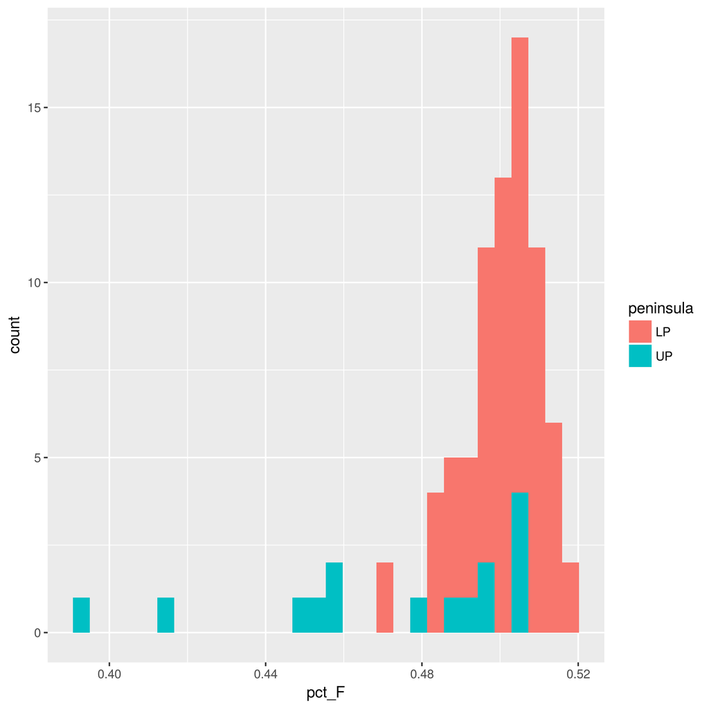

```r
knitr::include_graphics('images/histos_pctF_by_peninsula.png')
```

Confirm that the columns Professional, Service, Office, Construction, and Production sum up to 100 (within +- .105). There are a number of ways to do this. You could use `mutate` and/or use base R commands.

```r
 county_MI %>% mutate(tot_job_type = Professional + Service + Office + Construction + Production) %>%
 select(County, tot_job_type)
```

```
##            County tot_job_type
## 1          Alcona         99.9
## 2           Alger        100.0
## 3         Allegan        100.1
## 4          Alpena        100.0
## 5          Antrim        100.0
## 6          Arenac        100.0
## 7          Baraga        100.0
## 8           Barry        100.0
## 9             Bay        100.1
## 10         Benzie        100.1
## 11        Berrien        100.1
## 12         Branch        100.0
## 13        Calhoun         99.9
## 14           Cass         99.9
```

[output cut: 69 more lines]

### Summarization

Use county_MI.

Find total population by peninsula using dplyr.

```r
county_MI %>%
  group_by(peninsula) %>%
  summarise(TotalPop = sum(TotalPop))
```

```
## # A tibble: 2 x 2
##   peninsula TotalPop
##      <fctr>    <int>
## 1        LP  9591500
## 2        UP   309071
```

Number of counties by peninsula.

```r
county_MI %>%
  group_by(peninsula) %>%
  summarise(num_counties = n_distinct(County))
```

```
## # A tibble: 2 x 2
##   peninsula num_counties
##      <fctr>        <int>
## 1        LP           68
## 2        UP           15
```

Repeat the two previous queries using plyr instead of dplyr.

```r
 ddply(county_MI, .(peninsula), summarise, TotalPop = sum(TotalPop))
```

```
##   peninsula TotalPop
## 1        LP  9591500
## 2        UP   309071
```

```r
ddply(county_MI, .(peninsula), summarise, num_counties = n_distinct(County))
```

```
##   peninsula num_counties
## 1        LP           68
## 2        UP           15
```

Compute the following statistics for median Income by peninsula.

Let’s be perfectly clear, we are computing statistics based on medians which is not the same as computing the statistics by the grouping variables. We don’t have the raw data. So, we just need to be clear that these are summary stats of a median income.

- mean, median, 5% trimmed mean
- range, standard deviation, coefficient of variation, IQR
- 5th, 25th, 50th, 75th and 95th quantiles

```r
county_MI %>%
  group_by(peninsula)%>%
summarise(mean_Income = mean(Income),
          median_Income = median(Income),
          trim_Mean_Income = mean(Income, trim = 0.05),
          coefficient_variation = sd(Income)/mean(Income),
          IQR_Income = IQR(Income),
          quantile_Income_0.05 = quantile(Income, 0.05),
          quantile_Income_0.25 = quantile(Income, 0.25),
          quantile_Income_0.50 = quantile(Income, 0.50),
          quantile_Income_0.75 = quantile(Income, 0.75),
          quantile_Income_0.95 = quantile(Income, 0.95))
```

```
## # A tibble: 2 x 11
##   peninsula mean_Income median_Income trim_Mean_Income
##      <fctr>       <dbl>         <dbl>            <dbl>
## 1        LP    45718.66       43730.5         45301.97
## 2        UP    38781.67       38434.0         38781.67
## # ... with 7 more variables: coefficient_variation <dbl>,
## #   IQR_Income <dbl>, quantile_Income_0.05 <dbl>,
## #   quantile_Income_0.25 <dbl>, quantile_Income_0.50 <dbl>,
## #   quantile_Income_0.75 <dbl>, quantile_Income_0.95 <dbl>
```

Now look at the entire US. What are the 5th, 50th, and 95th percentile of median income by state? Sort in descending ordery by median of median income.

```r
county_df %>%
  group_by(State) %>%
  summarise( quantile_Income_0.05 = quantile(Income, 0.05, na.rm = TRUE),
     quantile_Income_0.50 = quantile(Income, 0.50, na.rm = TRUE),
      quantile_Income_0.95 = quantile(Income, 0.95, na.rm = TRUE)) %>%
  arrange(desc(quantile_Income_0.05, quantile_Income_0.50, quantile_Income_0.95))
```

```
## # A tibble: 51 x 4
##                   State quantile_Income_0.05 quantile_Income_0.50
##                  <fctr>                <dbl>                <dbl>
##  1 District of Columbia             70848.00              70848.0
##  2          Connecticut             60178.80              69228.0
##  3               Hawaii             54706.60              66250.0
##  4           New Jersey             53976.00              70471.0
##  5             Delaware             53873.50              54976.0
##  6         Rhode Island             52671.00              69526.0
##  7        Massachusetts             50284.25              63736.5
##  8        New Hampshire             47259.30              59246.5
##  9            Minnesota             43069.60              51665.0
## 10             New York             43029.35              50839.0
## # ... with 41 more rows, and 1 more variables: quantile_Income_0.95 <dbl>
```

Which states have the highest average percentage of production workers? Just return the top 10 states and their Production values.

```r
county_df %>%
  select(State, Production) %>%
  arrange(desc(Production)) %>%
  head(10)
```

```
##           State Production
## 1        Alaska       55.6
## 2        Alaska       40.9
## 3       Indiana       40.9
## 4   Mississippi       35.9
## 5       Indiana       34.9
## 6       Indiana       34.5
## 7      Nebraska       34.5
## 8  Pennsylvania       34.0
## 9       Georgia       33.5
## 10    Minnesota       33.1
```

Which states have the lowest average percentage of people who drive to work? Be careful about those NA values…

```r
county_df %>%
  select(State, Drive) %>%
  arrange((Drive)) %>%
  head(10, na.rm = TRUE)
```

```
##       State Drive
## 1    Alaska   5.2
## 2  New York   6.1
## 3    Alaska  16.5
## 4    Alaska  18.4
## 5  New York  18.6
## 6    Alaska  20.1
## 7    Alaska  21.2
## 8  New York  22.5
## 9    Alaska  25.8
## 10   Alaska  26.5
```

Which counties having a total population greater than 75000 have the lowest percentage of people who drive to work? Display State, County and Drive.

```r
county_df %>%
  filter(TotalPop > 75000) %>%
  select(State, County, Drive) %>%
arrange(Drive) %>%
head(10)
```

```
##                   State               County Drive
## 1              New York             New York   6.1
## 2              New York                Kings  18.6
## 3              New York                Bronx  22.5
## 4              New York               Queens  31.6
## 5  District of Columbia District of Columbia  33.7
## 6            California        San Francisco  35.9
## 7            New Jersey               Hudson  38.4
## 8         Massachusetts              Suffolk  40.8
## 9          Pennsylvania         Philadelphia  50.4
## 10             Virginia            Arlington  54.2
```

Repeat the previous query for the state of Michigan.

```r
county_MI %>%
  filter(TotalPop > 75000) %>%
  select(State, County, Drive) %>%
arrange(Drive) %>%
head(10)
```

```
##       State         County Drive
## 1  Michigan      Washtenaw  72.6
## 2  Michigan         Ingham  76.4
## 3  Michigan        Calhoun  80.8
## 4  Michigan          Wayne  81.0
## 5  Michigan Grand Traverse  81.4
## 6  Michigan           Kent  81.6
## 7  Michigan        Jackson  82.3
## 8  Michigan        Berrien  82.6
## 9  Michigan      St. Clair  82.6
## 10 Michigan      Kalamazoo  82.7
```

For this next question you do **not** need plyr or dplyr.

Create a correlation matrix for total population, per capita income and child poverty.

```r
cor_matrix <- county_df[c(7, 19, 22)]

cor(cor_matrix, use = "complete.obs")
```

```
##                 TotalPop IncomePerCap ChildPoverty
## TotalPop      1.00000000    0.2465392  -0.05014052
## IncomePerCap  0.24653921    1.0000000  -0.68692671
## ChildPoverty -0.05014052   -0.6869267   1.00000000
```

Write a few sentences interpreting the correlation matrix.

**All of the variables will be 100% correlated with themselves, so one can ingore those relationships. TotalPop is positively correlated with IncomePerCap, but weakly so, and is negatively correlated with Child Poverty, again insignificantly so. A strong downhill relationsihp does exist between IncomePerCap and ChildPoverty, which is intuitive, since poverty would naturally decline as Income level increased.**